# DIGITAL EPIDEMIOLOGY 2018

# 3.2 - Add new features to your model to include data from the preceding week

### Retrain the model with multiple linear regression and Lasso

**Introduce new features to the data set using dataframe shift operation**

```python
from sklearn.linear_model import LinearRegression
from sklearn.metrics import mean_squared_error, r2_score
from sklearn.model_selection import train_test_split

regress_df = pd.read_csv("regression_analysis.csv")

new_cols = []

for c in cols_meta[0]:
    cur_col = c + ' Prev'
    regress_df[cur_col] = regress_df[c].shift()
    new_cols.append(cur_col)

regress_df = regress_df.iloc[1:]
```

**Using linear regression:**

```
Mean squared error: 1.23
Variance score: -0.23
```

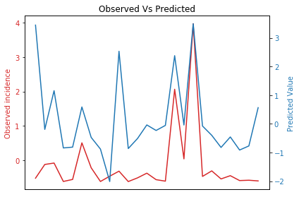

```python
cols_all = cols_meta[1] + new_cols


data = regress_df[cols_all]
target = regress_df[["Influnet"]]

X_train, X_test, y_train, y_test = train_test_split(data, target, shuffle=True,
                                                    test_size=0.3, random_state=49)

# Create linear regression object
regr = LinearRegression()

# Train the model using the training sets
regr.fit(X_train, y_train)

# Make predictions using the testing set
y_pred = regr.predict(X_test)

print("Mean squared error: %.2f"
      % mean_squared_error(y_test, y_pred))
print('Variance score: %.2f' % r2_score(y_test, y_pred))

fig, ax1 = plt.subplots()
x = np.arange(len(y_test))

color = 'tab:red'
ax1.set_ylabel('Observed incidence', color=color)
ax1.plot(x, y_test, color=color)
ax1.tick_params(axis='y', labelcolor=color)

ax2 = ax1.twinx()  # instantiate a second axes that shares the same x-axis

color = 'tab:blue'
ax2.set_ylabel('Predicted Value', color=color)  # we already handled the x-label with ax1
ax2.plot(x, y_pred, color=color)
ax2.tick_params(axis='y', labelcolor=color)

fig.tight_layout()  # otherwise the right y-label is slightly clipped
title = "Observed Vs Predicted"
plt.title(title)
plt.xticks(())
plt.show()
```

**Using LASSO:**

```
Mean squared error: 0.06
Variance score: 0.94
```

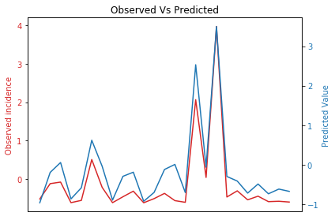

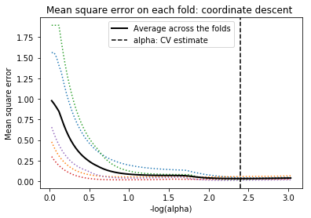

```python
model = LassoCV(cv=5).fit(X_train, y_train)

# Make predictions using the testing set
y_pred = model.predict(X_test)

print("Mean squared error: %.2f" % mean_squared_error(y_test, y_pred))
print('Variance score: %.2f' % r2_score(y_test, y_pred))

fig, ax1 = plt.subplots()
x = np.arange(len(y_test))

color = 'tab:red'
ax1.set_ylabel('Observed incidence', color=color)
ax1.plot(x, y_test, color=color)
ax1.tick_params(axis='y', labelcolor=color)

ax2 = ax1.twinx()  # instantiate a second axes that shares the same x-axis

color = 'tab:blue'
ax2.set_ylabel('Predicted Value', color=color)  # we already handled the x-label with ax1
ax2.plot(x, y_pred, color=color)
ax2.tick_params(axis='y', labelcolor=color)

fig.tight_layout()  # otherwise the right y-label is slightly clipped
title = "Observed Vs Predicted"
plt.title(title)
plt.xticks(())
plt.show()

# Display results
m_log_alphas = -np.log10(model.alphas_)

plt.plot(m_log_alphas, model.mse_path_, ':')
plt.plot(m_log_alphas, model.mse_path_.mean(axis=-1), 'k', label='Average across the folds', linewidth=2)
plt.axvline(-np.log10(model.alpha_), linestyle='--', color='k', label='alpha: CV estimate')
plt.legend()

plt.xlabel('-log(alpha)')
plt.ylabel('Mean square error')
plt.title('Mean square error on each fold: coordinate descent ')
plt.axis('tight')
plt.show()
```

## Consolidation of results

**Below are the results we obtained,**

**3.1** -

**Multiple linear regression** - Mean squared error: **0.18** Variance score: **0.89**

**LASSO** - Mean squared error: 0.06 Variance score: 0.94

**3.2** -

**Multiple linear regression** - Mean squared error: **1.23** Variance score: **-0.23**

**LASSO** - Mean squared error: **0.06** Variance score: **0.94**

As we can observe, with the actual dataset both the regression model performed comparitively well with LASSO having the best performance. With new features (pertaining to preceeding weeks data) added the performance of the multiple linear regression model decreased multiflold where as the performance of the LASSO model remained the same irrepective of the new features. so we conclude our regression analysis that, for good prediction performance of the Influnet prevalence LASSO is a good choice